# solar_simulator

Fabian C. Salgado-Roa

2024-02-07

# Termal differences black morph vs black-and-white morph

In this file, we will analyzed the data measured on the solar simulator

```r
setwd("C:/Users/Fabian C. Salgado/Dropbox/PhD_FabianSalgado/research_proposal/aim2/temp_measures")
```

Load necessary libraries

```r
library(tidyverse)
library(car)
```

Read the CSV file containing temperature measures

```r
ref <- read_csv("../temp_measures_lab.csv", col_names = TRUE)
```

## Functions for calculations

Define a function to calculate standard error

```r
se <- function(x) {
  sd(x) / sqrt(length(x))
}
```

### Function to calculate heating rates and slope

the following function computes the overall change in temperature (delta) and the maximum rate of change of temperature (slope) based on the provided temperature measures and a specified time interval.

```r
ht <- function(heating, time_interval = 10) {
  delta <- heating[length(heating)] - heating[1]
  tmp_slope <- c()
  count = 1
  while (count < length(heating)) {
    tmp <- (heating[count + 2] - heating[count]) / time_interval
    tmp_slope <- c(tmp_slope, tmp)
    count = count + 1
  }
  slope <- max(na.omit(tmp_slope))
  return(c(delta, slope))
}
```

## Summary calculations per side

### Ventral side

Using the ventral side measures of both black and black-and-white colour morphs calculate the overall change in temperature (delta) and the maximum rate of change of temperature (slope)

```r
# Create an empty tibble to store data
datos <- tibble(
  code = character(),
  morph = character(),
  side = character(),
  delta_temp = double(),
  slope = character(),
  weight = double(),
  width = double()
)


for (arch in list.files(pattern = "*_v.TXT")) {
  df <- read_delim(arch, col_names = FALSE, delim = "\t")
  tmp <- df[, 4]
  colnames(tmp) <- c("temp_egg")
  code <- arch %>% str_replace("_v.TXT", "")
  measures <- ht(heating = tmp$temp_egg, time_interval = 20)
  morph <- ref$morph[grepl(paste0("\\b", code, "\\b"), ref$code)]
  weight <- ref$weight[grepl(paste0("\\b", code, "\\b"), ref$code)]
  width <- ref$width[grepl(paste0("\\b", code, "\\b"), ref$code)]
  tmp <- tibble(
    code = code,
    side = "ventral",
    delta_temp = measures[1],
    slope = measures[2],
    morph = morph,
    weight = weight,
    width = width
  )
  datos <- rbind(datos, tmp)
}

ventral<-datos
```

### Dorsal side

Using the dorsal side measures of both black and black-and-white colour morphs calculate the overall change in temperature (delta) and the maximum rate of change of temperature (slope)

```r
# Create an empty tibble to store data
datos <- tibble(
  code = character(),
  morph = character(),
  side = character(),
  delta_temp = double(),
  slope = character(),
  weight = double(),
  width = double()
)


for (arch in list.files(pattern = "*_d.TXT")) {
  df <- read_delim(arch, col_names = FALSE, delim = "\t")
  tmp <- df[, 4]
  colnames(tmp) <- c("temp_egg")
  code <- arch %>% str_replace("_d.TXT", "")
  measures <- ht(heating = tmp$temp_egg, time_interval = 20)
  morph <- ref$morph[grepl(paste0("\\b", code, "\\b"), ref$code)]
  weight <- ref$weight[grepl(paste0("\\b", code, "\\b"), ref$code)]
  width <- ref$width[grepl(paste0("\\b", code, "\\b"), ref$code)]
  tmp <- tibble(
    code = code,
    side = "dorsal",
    delta_temp = measures[1],
    slope = measures[2],
    morph = morph,
    weight = weight,
    width = width
  )
  datos <- rbind(datos, tmp)
}

dorsal<-datos
```

## Morph differences in heating rates

### Discard differences in weight and size between colour morphs

#### Weight

```r
morph_weight <- lm(weight ~ morph, data = ventral) # no association
summary(morph_weight)
```

```
##
## Call:
## lm(formula = weight ~ morph, data = ventral)
##
## Residuals:
##       Min        1Q    Median        3Q       Max
## -0.046864 -0.017727  0.002273  0.013136  0.073136
##
## Coefficients:
##               Estimate Std. Error t value Pr(>|t|)
## (Intercept)  0.0977273  0.0059257  16.492   <2e-16 ***
## morphwhite  -0.0008636  0.0083802  -0.103    0.918
## ---
## Signif. codes:  0 '***' 0.001 '**' 0.01 '*' 0.05 '.' 0.1 ' ' 1
##
## Residual standard error: 0.02779 on 42 degrees of freedom
## Multiple R-squared:  0.0002528,  Adjusted R-squared:  -0.02355
## F-statistic: 0.01062 on 1 and 42 DF,  p-value: 0.9184
```

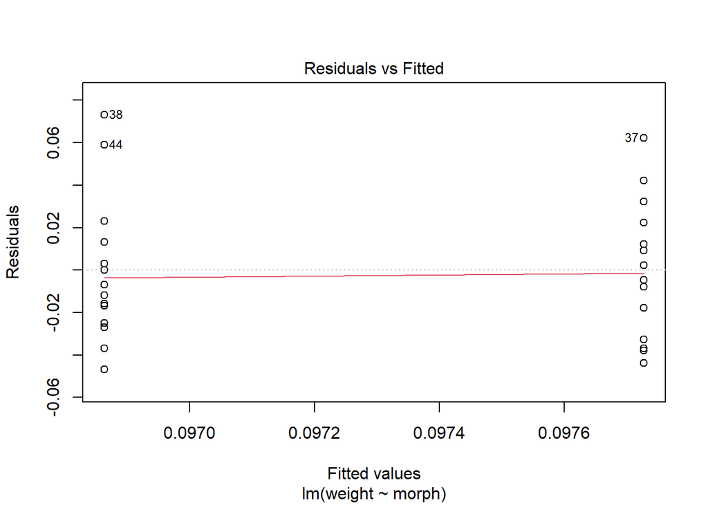

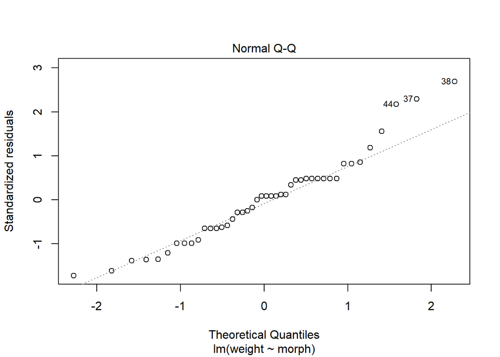

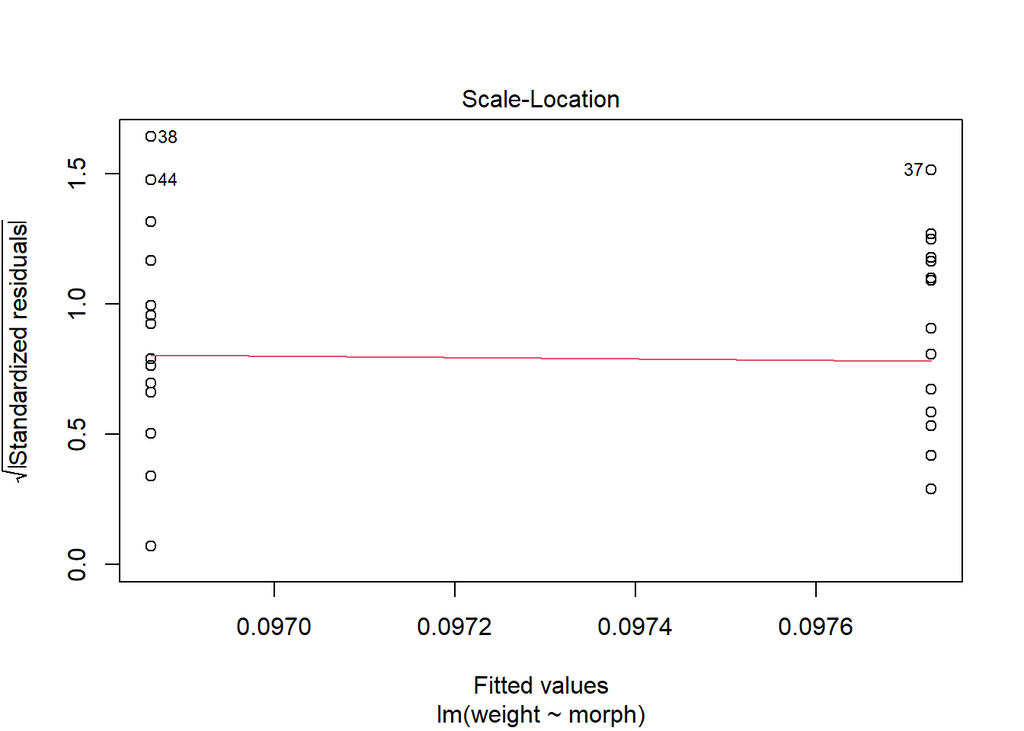

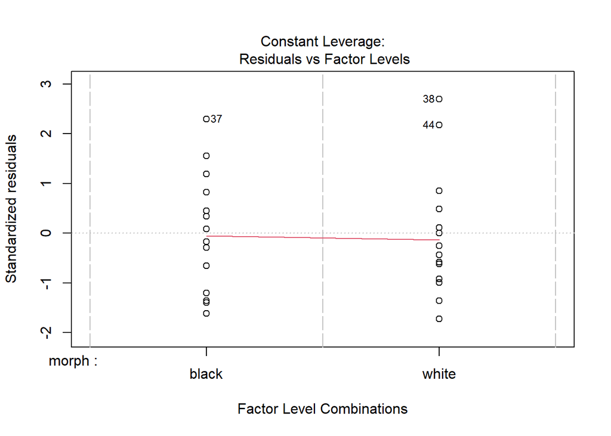

```r
plot(morph_weight)
```

```r
anova(morph_weight)
```

|  | Df | Sum Sq | Mean Sq | F value | Pr(>F) |
| --- | --- | --- | --- | --- | --- |
| morph | 1 | 8.204545e-06 | 8.204545e-06 | 0.01062079 | 0.9184081 |
| Residuals | 42 | 3.244495e-02 | 7.724989e-04 | NA | NA |

There is not differences in weight between the colour morphs

#### Size

```r
morph_width <- lm(width ~ morph, data = ventral) # no association
summary(morph_width)
```

```
##
## Call:
## lm(formula = width ~ morph, data = ventral)
##
## Residuals:
##      Min       1Q   Median       3Q      Max
## -1.40091 -0.41341 -0.07864  0.31966  1.62136
##
## Coefficients:
##             Estimate Std. Error t value Pr(>|t|)
## (Intercept)  7.80091    0.14273  54.654   <2e-16 ***
## morphwhite   0.07773    0.20186   0.385    0.702
## ---
## Signif. codes:  0 '***' 0.001 '**' 0.01 '*' 0.05 '.' 0.1 ' ' 1
##
## Residual standard error: 0.6695 on 42 degrees of freedom
## Multiple R-squared:  0.003518,   Adjusted R-squared:  -0.02021
## F-statistic: 0.1483 on 1 and 42 DF,  p-value: 0.7021
```

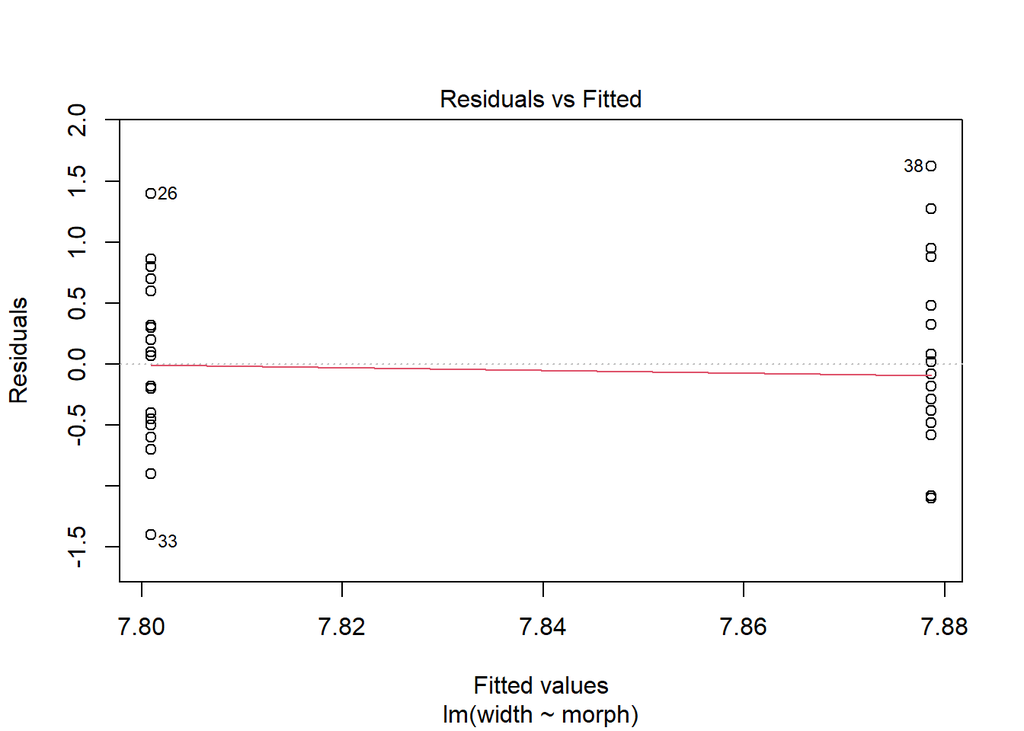

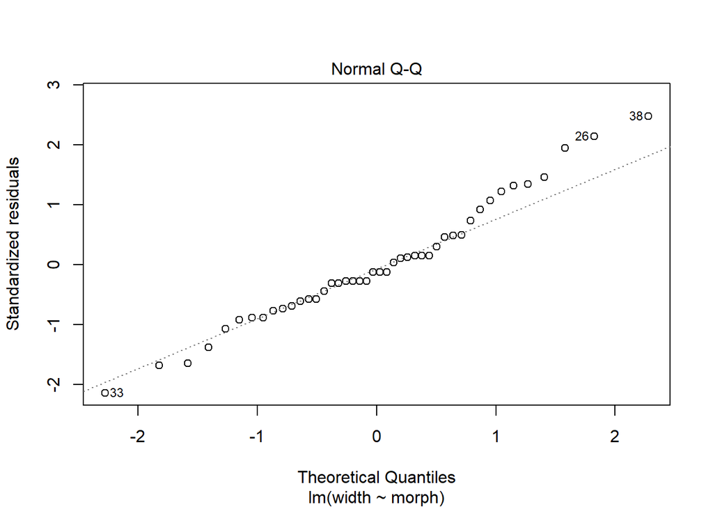

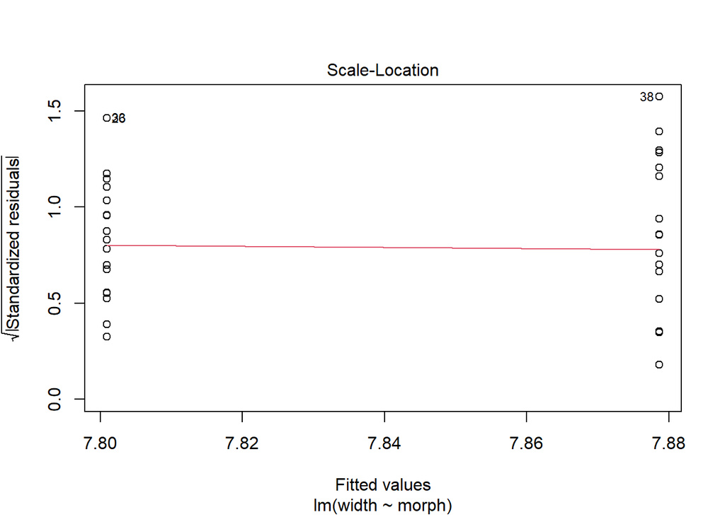

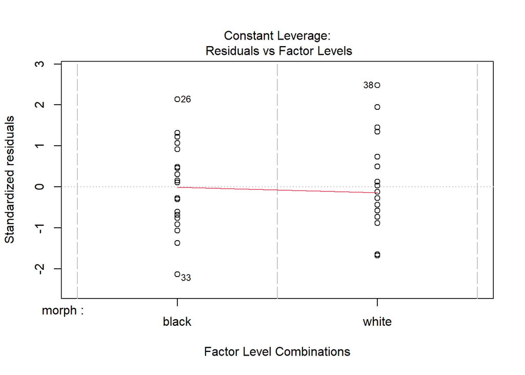

```r
plot(morph_width)
```

```r
anova(morph_width)
```

|  | Df | Sum Sq | Mean Sq | F value | Pr(>F) |
| --- | --- | --- | --- | --- | --- |
| morph | 1 | 0.06645682 | 0.06645682 | 0.1482746 | 0.7021329 |
| Residuals | 42 | 18.82444091 | 0.44820097 | NA | NA |

There is not differences in width between the colour morphs

### Overall change in temperature

Let’s make comparisons per side

#### Ventral side

```r
ventral_temp <- lm(delta_temp ~ weight + morph , data = ventral)
summary(ventral_temp)
```

```
##
## Call:
## lm(formula = delta_temp ~ weight + morph, data = ventral)
##
## Residuals:
##      Min       1Q   Median       3Q      Max
## -1.61996 -0.37348 -0.03509  0.31100  1.64385
##
## Coefficients:
##             Estimate Std. Error t value Pr(>|t|)
## (Intercept)   4.7044     0.4019  11.705 1.19e-14 ***
## weight       -0.6031     3.8276  -0.158   0.8756
## morphwhite   -0.5596     0.2079  -2.692   0.0102 *
## ---
## Signif. codes:  0 '***' 0.001 '**' 0.01 '*' 0.05 '.' 0.1 ' ' 1
##
## Residual standard error: 0.6894 on 41 degrees of freedom
## Multiple R-squared:  0.1504, Adjusted R-squared:  0.109
## F-statistic: 3.629 on 2 and 41 DF,  p-value: 0.03538
```

```r
anova(ventral_temp)
```

|  | Df | Sum Sq | Mean Sq | F value | Pr(>F) |
| --- | --- | --- | --- | --- | --- |
| weight | 1 | 0.006263084 | 0.006263084 | 0.0131762 | 0.9091738 |
| morph | 1 | 3.443947957 | 3.443947957 | 7.2453375 | 0.0102435 |
| Residuals | 41 | 19.488652595 | 0.475332990 | NA | NA |

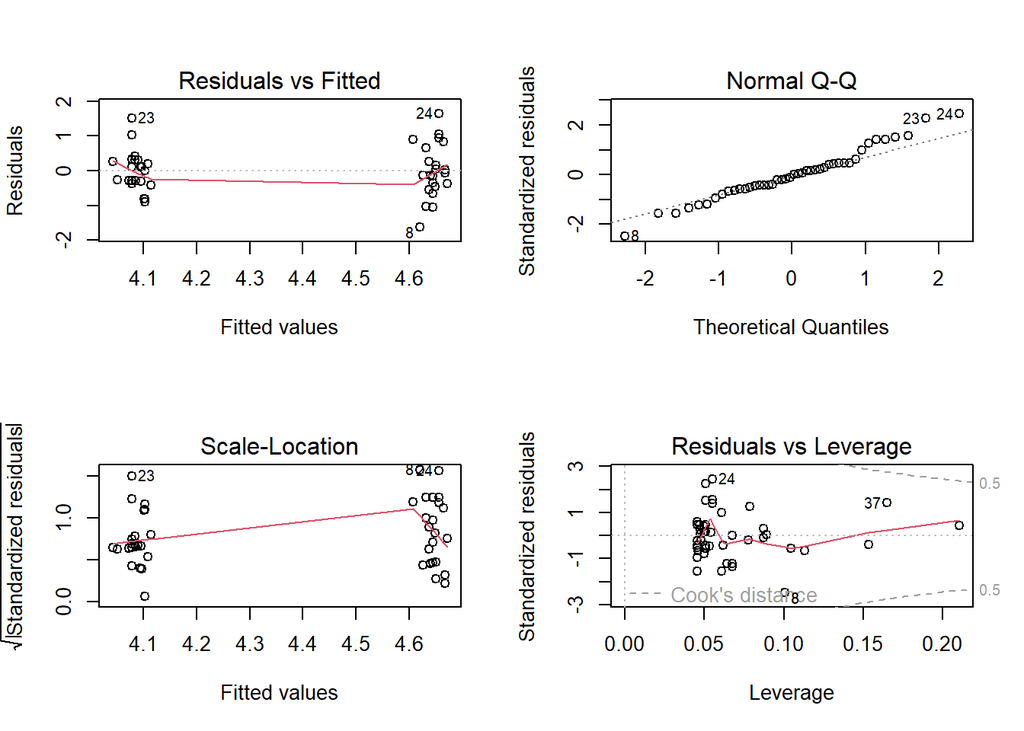

```r
par(mfrow=c(2,2))
plot(ventral_temp)
```

Dark individuals heat faster than black-and-white individuals on their ventral side

#### Dorsal side

```r
dorsal_temp <- lm(delta_temp ~ weight + morph, data = dorsal)
summary(dorsal_temp)
```

```
##
## Call:
## lm(formula = delta_temp ~ weight + morph, data = dorsal)
##
## Residuals:
##      Min       1Q   Median       3Q      Max
## -1.15653 -0.31554 -0.05831  0.37308  1.22392
##
## Coefficients:
##             Estimate Std. Error t value Pr(>|t|)
## (Intercept)   5.4715     0.3231  16.932   <2e-16 ***
## weight       -7.0112     3.0775  -2.278    0.028 *
## morphwhite   -0.4242     0.1672  -2.538    0.015 *
## ---
## Signif. codes:  0 '***' 0.001 '**' 0.01 '*' 0.05 '.' 0.1 ' ' 1
##
## Residual standard error: 0.5543 on 41 degrees of freedom
## Multiple R-squared:  0.2183, Adjusted R-squared:  0.1802
## F-statistic: 5.725 on 2 and 41 DF,  p-value: 0.006416
```

```r
anova(dorsal_temp)# both are significat
```

|  | Df | Sum Sq | Mean Sq | F value | Pr(>F) |
| --- | --- | --- | --- | --- | --- |
| weight | 1 | 1.539273 | 1.5392733 | 5.009242 | 0.03070549 |
| morph | 1 | 1.979246 | 1.9792461 | 6.441041 | 0.01504731 |
| Residuals | 41 | 12.598753 | 0.3072867 | NA | NA |

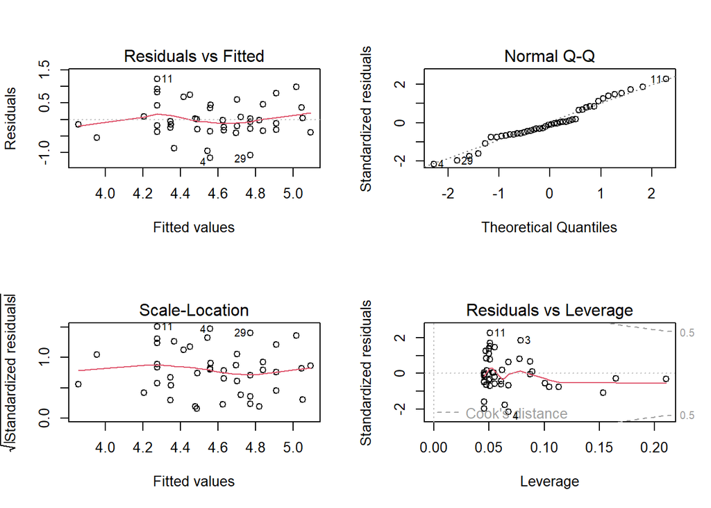

```r
par(mfrow=c(2,2))
plot(dorsal_temp)
```

```r
### Discard interaction
dorsal_temp_int <- lm(delta_temp ~ weight * morph, data = dorsal)
Anova(dorsal_temp_int,type=3)
```

|  | Sum Sq | Df | F value | Pr(>F) |
| --- | --- | --- | --- | --- |
| (Intercept) | 49.6442514 | 1 | 162.399220 | 1.149527e-15 |
| weight | 1.7017149 | 1 | 5.566751 | 2.327419e-02 |
| morph | 0.9290720 | 1 | 3.039235 | 8.895703e-02 |
| weight:morph | 0.3710464 | 1 | 1.213789 | 2.771683e-01 |
| Residuals | 12.2277069 | 40 | NA | NA |

Dark individuals heat faster than black-and-white individuals on their dorsal side

#### Summary plot overall change in temperature

Get predicted values based on the models

```r
ventral$delta_predict <- predict(ventral_temp, type = "response")
dorsal$delta_predict <- predict(dorsal_temp, type = "response")
total <- rbind(ventral, dorsal)
```

Summary plot

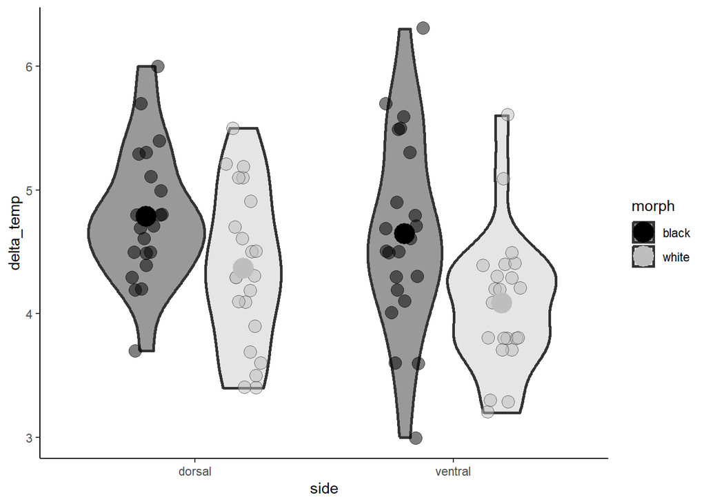

```r
w_col<-"gray"
b_col<-"black"

par(mfrow=c(1,1))
# Total plot
ggplot(data = total, aes(x = side, y = delta_temp, fill = morph)) +
  scale_fill_viridis_d(option = "D") +
  geom_violin(alpha = 0.4, position = position_dodge(width = .75), size = 1) +
  geom_point(shape = 21, size = 4, position = position_jitterdodge(jitter.width = 0.15, jitter.height = 0.01), alpha = 0.5) +
  scale_fill_manual(values = c("black" = b_col,"white" = w_col))+
  stat_summary(
    fun = mean,
    aes(x = side, y = delta_predict, color = morph, group = morph),
    fun.min = function(x) mean(x) - 2 * se(x),
    fun.max = function(x) mean(x) + 2 * se(x),
    geom = "pointrange",
    position = position_dodge(width = .75),
    size = 1.5
  ) +
  theme_classic()+
  scale_colour_manual(values = c("black" = b_col,"white" = w_col))
```

### maximum rate of temperature change

Let’s make comparisons per side

#### Ventral side

```r
ventral_slope <- lm(slope ~ weight + morph , data = ventral)
summary(ventral_slope)
```

```
##
## Call:
## lm(formula = slope ~ weight + morph, data = ventral)
##
## Residuals:
##        Min         1Q     Median         3Q        Max
## -0.0157285 -0.0037824  0.0000575  0.0032882  0.0162924
##
## Coefficients:
##              Estimate Std. Error t value Pr(>|t|)
## (Intercept)  0.049875   0.004036  12.358 2.08e-15 ***
## weight      -0.101045   0.038437  -2.629  0.01200 *
## morphwhite  -0.006224   0.002088  -2.981  0.00482 **
## ---
## Signif. codes:  0 '***' 0.001 '**' 0.01 '*' 0.05 '.' 0.1 ' ' 1
##
## Residual standard error: 0.006923 on 41 degrees of freedom
## Multiple R-squared:  0.275,  Adjusted R-squared:  0.2396
## F-statistic: 7.776 on 2 and 41 DF,  p-value: 0.001371
```

```r
anova(ventral_slope)
```

|  | Df | Sum Sq | Mean Sq | F value | Pr(>F) |
| --- | --- | --- | --- | --- | --- |
| weight | 1 | 0.0003195107 | 3.195107e-04 | 6.665539 | 0.013501424 |
| morph | 1 | 0.0004259616 | 4.259616e-04 | 8.886286 | 0.004816031 |
| Residuals | 41 | 0.0019653232 | 4.793471e-05 | NA | NA |

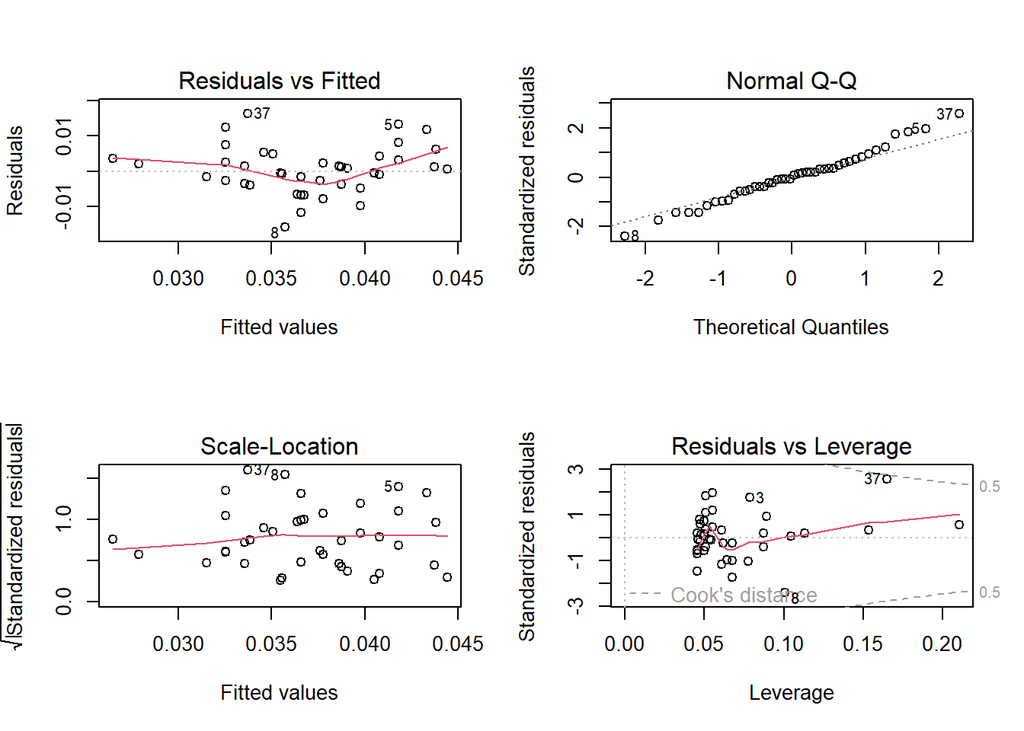

```r
par(mfrow=c(2,2))
plot(ventral_slope)
```

```r
ventral_slope_int <- lm(slope ~ weight * morph, data = ventral)
summary(ventral_slope_int)
```

```
##
## Call:
## lm(formula = slope ~ weight * morph, data = ventral)
##
## Residuals:
##        Min         1Q     Median         3Q        Max
## -0.0122222 -0.0037916 -0.0004233  0.0031884  0.0214576
##
## Coefficients:
##                    Estimate Std. Error t value Pr(>|t|)
## (Intercept)        0.057981   0.005511  10.522 4.37e-13 ***
## weight            -0.183991   0.054483  -3.377  0.00164 **
## morphwhite        -0.021192   0.007495  -2.828  0.00729 **
## weight:morphwhite  0.153794   0.074188   2.073  0.04465 *
## ---
## Signif. codes:  0 '***' 0.001 '**' 0.01 '*' 0.05 '.' 0.1 ' ' 1
##
## Residual standard error: 0.006661 on 40 degrees of freedom
## Multiple R-squared:  0.3453, Adjusted R-squared:  0.2962
## F-statistic: 7.033 on 3 and 40 DF,  p-value: 0.000659
```

```r
Anova(ventral_slope_int,type=3)
```

|  | Sum Sq | Df | F value | Pr(>F) |
| --- | --- | --- | --- | --- |
| (Intercept) | 0.0049116877 | 1 | 110.707220 | 4.365468e-13 |
| weight | 0.0005059759 | 1 | 11.404468 | 1.642211e-03 |
| morph | 0.0003547248 | 1 | 7.995336 | 7.291081e-03 |
| weight:morph | 0.0001906647 | 1 | 4.297496 | 4.465346e-02 |
| Residuals | 0.0017746585 | 40 | NA | NA |

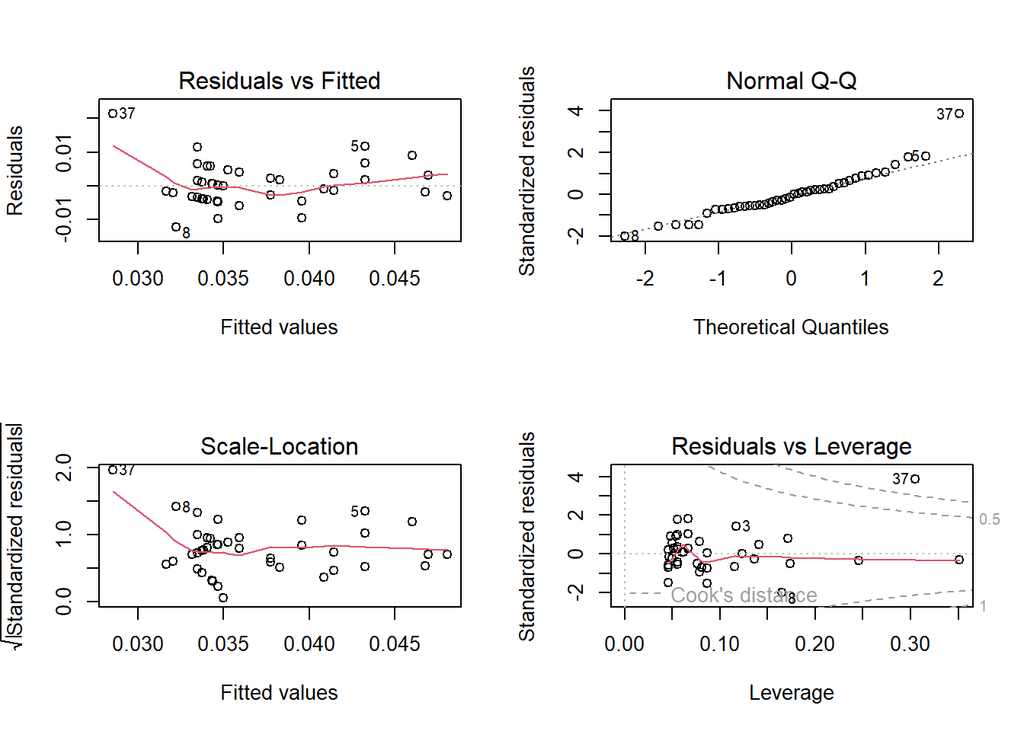

```r
par(mfrow=c(2,2))
plot(ventral_slope_int)
```

Dark individuals have higher maximum rate of temperature change than black-and-white individuals on their ventral side. the interaction term with weight is also significant

#### Dorsal side

```r
dorsal_slope <- lm(slope ~ weight + morph , data = dorsal)
summary(dorsal_slope)
```

```
##
## Call:
## lm(formula = slope ~ weight + morph, data = dorsal)
##
## Residuals:
##        Min         1Q     Median         3Q        Max
## -0.0105452 -0.0049357 -0.0005452  0.0050043  0.0200043
##
## Coefficients:
##              Estimate Std. Error t value Pr(>|t|)
## (Intercept)  0.057422   0.003753  15.301  < 2e-16 ***
## weight      -0.138738   0.035742  -3.882 0.000369 ***
## morphwhite  -0.007165   0.001941  -3.691 0.000652 ***
## ---
## Signif. codes:  0 '***' 0.001 '**' 0.01 '*' 0.05 '.' 0.1 ' ' 1
##
## Residual standard error: 0.006438 on 41 degrees of freedom
## Multiple R-squared:  0.4079, Adjusted R-squared:  0.379
## F-statistic: 14.12 on 2 and 41 DF,  p-value: 2.161e-05
```

```r
anova(dorsal_slope)
```

|  | Df | Sum Sq | Mean Sq | F value | Pr(>F) |
| --- | --- | --- | --- | --- | --- |
| weight | 1 | 0.0006059252 | 6.059252e-04 | 14.61907 | 0.0004397015 |
| morph | 1 | 0.0005646099 | 5.646099e-04 | 13.62226 | 0.0006515800 |
| Residuals | 41 | 0.0016993513 | 4.144759e-05 | NA | NA |

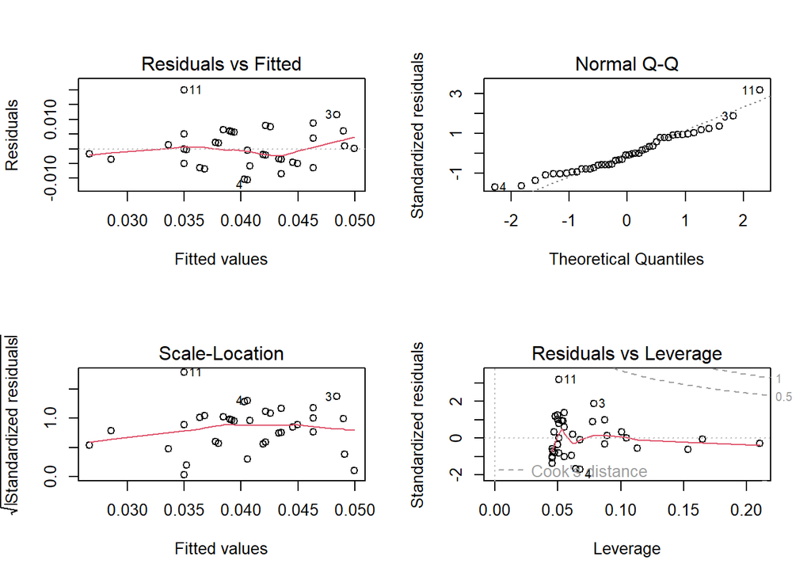

```r
par(mfrow=c(2,2))
plot(dorsal_slope)
```

```r
dorsal_slope_int <- lm(slope ~ weight * morph, data = dorsal)
summary(dorsal_slope_int)
```

```
##
## Call:
## lm(formula = slope ~ weight * morph, data = dorsal)
##
## Residuals:
##        Min         1Q     Median         3Q        Max
## -0.0096883 -0.0050124 -0.0006317  0.0045853  0.0195853
##
## Coefficients:
##                    Estimate Std. Error t value Pr(>|t|)
## (Intercept)        0.061072   0.005331  11.457 3.32e-14 ***
## weight            -0.176084   0.052705  -3.341  0.00182 **
## morphwhite        -0.013905   0.007250  -1.918  0.06229 .
## weight:morphwhite  0.069244   0.071766   0.965  0.34041
## ---
## Signif. codes:  0 '***' 0.001 '**' 0.01 '*' 0.05 '.' 0.1 ' ' 1
##
## Residual standard error: 0.006443 on 40 degrees of freedom
## Multiple R-squared:  0.4213, Adjusted R-squared:  0.3779
## F-statistic: 9.708 on 3 and 40 DF,  p-value: 6.101e-05
```

```r
Anova(dorsal_slope_int,type=3)
```

|  | Sum Sq | Df | F value | Pr(>F) |
| --- | --- | --- | --- | --- |
| (Intercept) | 5.449319e-03 | 1 | 131.253526 | 3.321014e-14 |
| weight | 4.634215e-04 | 1 | 11.162075 | 1.817780e-03 |
| morph | 1.527087e-04 | 1 | 3.678177 | 6.228836e-02 |
| weight:morph | 3.865101e-05 | 1 | 0.930957 | 3.404118e-01 |
| Residuals | 1.660700e-03 | 40 | NA | NA |

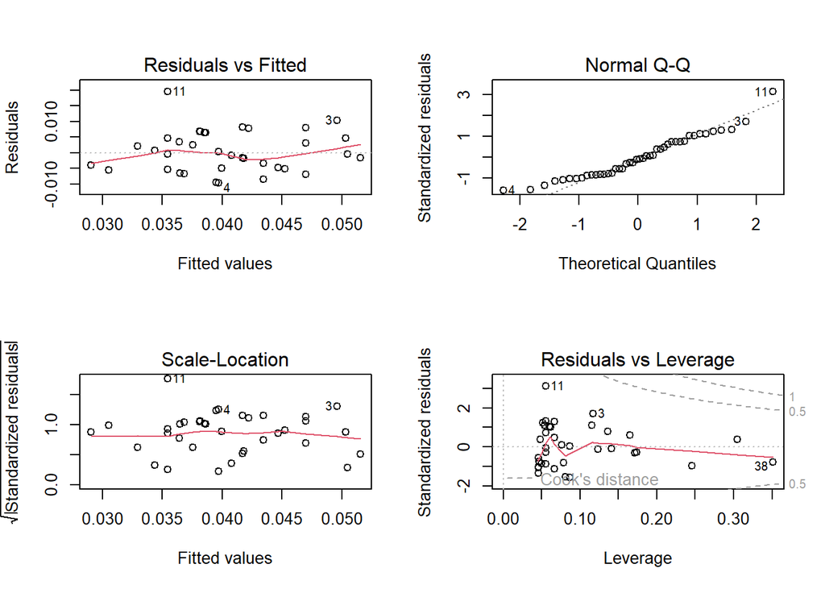

```r
par(mfrow=c(2,2))
plot(dorsal_slope_int)
```

Dark individuals have higher maximum rate of temperature change than black-and-white individuals on their dorsal side. the interaction term with weight is not significant

#### Summary plots maximum rate of temperature change

```r
ventral$slope_predict <- predict(ventral_slope, type = "response")
dorsal$slope_predict <- predict(dorsal_slope, type = "response")
total <- rbind(ventral, dorsal)
```

Let’s explore the significant interaction term found on the ventral side

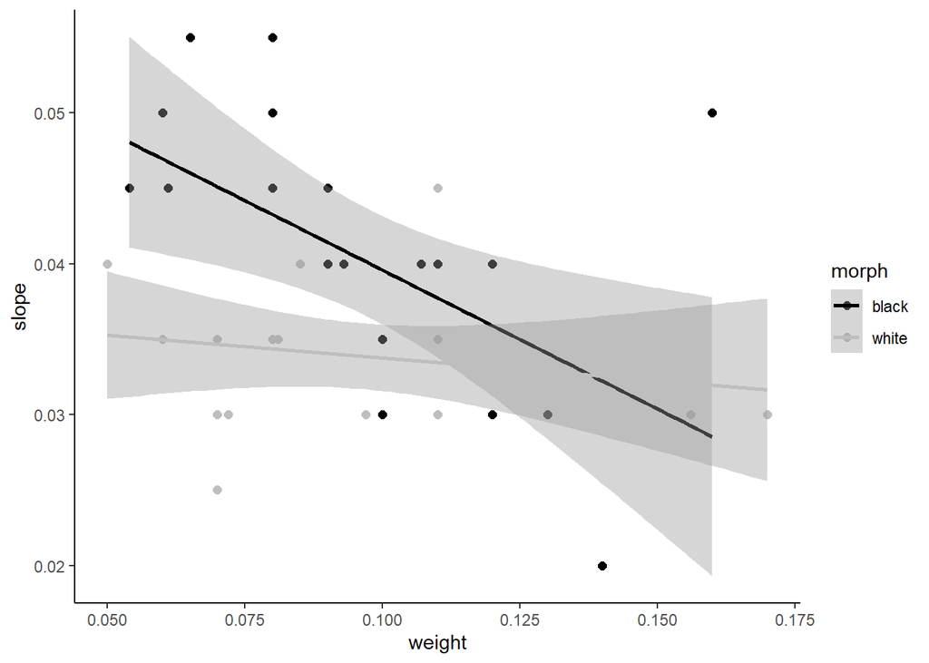

```r
par(mfrow=c(1,1))
ggplot(data = ventral, aes(x = weight, y = slope, col = morph))+geom_point(size=2)+geom_smooth(method = "lm", se = TRUE)+scale_colour_manual(values = c("black" = b_col,"white" = w_col))+theme_classic()
```

Total plot

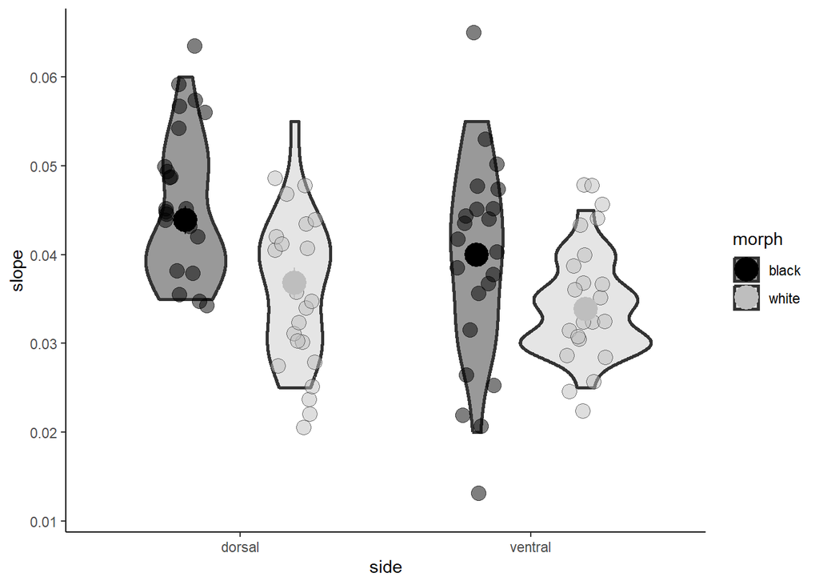

```r
par(mfrow=c(1,1))
ggplot(data = total, aes(x = side, y = slope, fill = morph)) +
  scale_fill_viridis_d(option = "D") +
  geom_violin(alpha = 0.4, position = position_dodge(width = .75), size = 1) +
  geom_point(shape = 21, size = 4, position = position_jitterdodge(jitter.width = 0.15, jitter.height = 0.01), alpha = 0.5) +
  scale_fill_manual(values = c("black" = b_col,"white" = w_col))+
  stat_summary(
    fun = mean,
    aes(x = side, y = slope_predict, color = morph, group = morph),
    fun.min = function(x) mean(x) - 2 * se(x),
    fun.max = function(x) mean(x) + 2 * se(x),
    geom = "pointrange",
    position = position_dodge(width = .75),
    size = 1.5
  ) +
  theme_classic()+
  scale_colour_manual(values = c("black" = b_col,"white" = w_col))
```